# PGP-Retail

Problem Statement:

It is a critical requirement for business to understand the value derived from a customer. RFM is a method used for analyzing customer value. Customer segmentation is the practice of segregating the customer base into groups of individuals based on some common characteristics such as age, gender, interests, and spending habits Perform customer segmentation using RFM analysis. The resulting segments can be ordered from most valuable (highest recency, frequency, and value) to least valuable (lowest recency, frequency, and value).

# Project Task: Week 1

Data Cleaning:

1. Perform a preliminary data inspection and data cleaning.

a. Check for missing data and formulate an apt strategy to treat them.

b. Remove duplicate data records.

c. Perform descriptive analytics on the given data.

Data Transformation:

1. Perform cohort analysis (a cohort is a group of subjects that share a defining characteristic). Observe how a cohort behaves across time and compare it to other cohorts.

a. Create month cohorts and analyze active customers for each cohort.

b. Analyze the retention rate of customers.

```python
#Importing Required libraries
import numpy as np
import pandas as pd
import matplotlib.pyplot as plt
import seaborn as sns
import warnings
warnings.filterwarnings('ignore')
```

```python
#Importing train dataset
data_train=pd.read_excel('train.xlsx',parse_dates=['InvoiceDate'],infer_datetime_format=True)
data_train.head()
```

|  | InvoiceNo | StockCode | Description | Quantity | InvoiceDate | UnitPrice | CustomerID | Country |
| --- | --- | --- | --- | --- | --- | --- | --- | --- |
| 0 | 558904 | 22292 | HANGING CHICK YELLOW DECORATION | 1 | 2011-07-04 16:18:00 | 1.25 | NaN | United Kingdom |
| 1 | 556072 | 20970 | PINK FLORAL FELTCRAFT SHOULDER BAG | 8 | 2011-06-08 14:57:00 | 3.75 | 16126.0 | United Kingdom |
| 2 | 551739 | 21559 | STRAWBERRY LUNCH BOX WITH CUTLERY | 2 | 2011-05-04 10:58:00 | 2.55 | 18118.0 | United Kingdom |
| 3 | 541658 | 21988 | PACK OF 6 SKULL PAPER PLATES | 1 | 2011-01-20 12:16:00 | 0.85 | 15529.0 | United Kingdom |
| 4 | 538364 | 85099C | JUMBO BAG BAROQUE BLACK WHITE | 10 | 2010-12-10 17:26:00 | 1.95 | 14448.0 | United Kingdom |

```python
data_train.shape
```

```
(379336, 8)
```

```python
#Importing test dataset
data_test=pd.read_excel('test.xlsx',parse_dates=['InvoiceDate'],infer_datetime_format=True)
data_test.head()
```

|  | InvoiceNo | StockCode | Description | Quantity | InvoiceDate | UnitPrice | CustomerID | Country |
| --- | --- | --- | --- | --- | --- | --- | --- | --- |
| 0 | 562955 | 84660c | PINK STITCHED WALL CLOCK | 3 | 2011-08-11 10:14:00 | 7.46 | NaN | United Kingdom |
| 1 | 548451 | 22707 | WRAP MONSTER FUN | 50 | 2011-03-31 11:25:00 | 0.42 | 17365.0 | United Kingdom |
| 2 | 568180 | 22534 | MAGIC DRAWING SLATE SPACEBOY | 12 | 2011-09-25 13:42:00 | 0.42 | 15429.0 | United Kingdom |
| 3 | 577078 | 47369B | BLUE GREEN EMBROIDERY COSMETIC BAG | 1 | 2011-11-17 15:17:00 | 5.79 | NaN | United Kingdom |
| 4 | C569891 | 22720 | SET OF 3 CAKE TINS PANTRY DESIGN | -2 | 2011-10-06 15:46:00 | 4.95 | 13924.0 | United Kingdom |

```python
data_test.shape
```

```
(162573, 8)
```

```python
#Appending train and test datasets into one:
data_final=pd.concat([data_train,data_test])
data_final.head()
```

|  | InvoiceNo | StockCode | Description | Quantity | InvoiceDate | UnitPrice | CustomerID | Country |
| --- | --- | --- | --- | --- | --- | --- | --- | --- |
| 0 | 558904 | 22292 | HANGING CHICK YELLOW DECORATION | 1 | 2011-07-04 16:18:00 | 1.25 | NaN | United Kingdom |
| 1 | 556072 | 20970 | PINK FLORAL FELTCRAFT SHOULDER BAG | 8 | 2011-06-08 14:57:00 | 3.75 | 16126.0 | United Kingdom |
| 2 | 551739 | 21559 | STRAWBERRY LUNCH BOX WITH CUTLERY | 2 | 2011-05-04 10:58:00 | 2.55 | 18118.0 | United Kingdom |
| 3 | 541658 | 21988 | PACK OF 6 SKULL PAPER PLATES | 1 | 2011-01-20 12:16:00 | 0.85 | 15529.0 | United Kingdom |
| 4 | 538364 | 85099C | JUMBO BAG BAROQUE BLACK WHITE | 10 | 2010-12-10 17:26:00 | 1.95 | 14448.0 | United Kingdom |

```python
#Size of the dataset
data_final.shape
```

```
(541909, 8)
```

```python
#Viewing the top few rows
data_final.head(n=10)
```

|  | InvoiceNo | StockCode | Description | Quantity | InvoiceDate | UnitPrice | CustomerID | Country |
| --- | --- | --- | --- | --- | --- | --- | --- | --- |
| 0 | 558904 | 22292 | HANGING CHICK YELLOW DECORATION | 1 | 2011-07-04 16:18:00 | 1.25 | NaN | United Kingdom |
| 1 | 556072 | 20970 | PINK FLORAL FELTCRAFT SHOULDER BAG | 8 | 2011-06-08 14:57:00 | 3.75 | 16126.0 | United Kingdom |
| 2 | 551739 | 21559 | STRAWBERRY LUNCH BOX WITH CUTLERY | 2 | 2011-05-04 10:58:00 | 2.55 | 18118.0 | United Kingdom |
| 3 | 541658 | 21988 | PACK OF 6 SKULL PAPER PLATES | 1 | 2011-01-20 12:16:00 | 0.85 | 15529.0 | United Kingdom |
| 4 | 538364 | 85099C | JUMBO BAG BAROQUE BLACK WHITE | 10 | 2010-12-10 17:26:00 | 1.95 | 14448.0 | United Kingdom |
| 5 | 552306 | 84789 | ENCHANTED BIRD PLANT CAGE | 4 | 2011-05-08 15:20:00 | 3.75 | 13911.0 | United Kingdom |
| 6 | 561513 | 72351B | SET/6 PINK BUTTERFLY T-LIGHTS | 1 | 2011-07-27 15:12:00 | 4.13 | NaN | United Kingdom |
| 7 | 566591 | 23057 | BEADED CHANDELIER T-LIGHT HOLDER | 4 | 2011-09-13 14:53:00 | 4.95 | 16036.0 | United Kingdom |
| 8 | 564516 | 84970l | SINGLE HEART ZINC T-LIGHT HOLDER | 3 | 2011-08-25 14:45:00 | 2.08 | NaN | United Kingdom |
| 9 | 573582 | 23082 | SET 6 PAPER TABLE LANTERN HEARTS | 6 | 2011-10-31 14:23:00 | 3.75 | 16633.0 | United Kingdom |

```python
type(data_final)
```

```
pandas.core.frame.DataFrame
```

```python
#As invoice number starting with "C" is cancellation and not required for our model..henceforth removing those rows
data_final[data_final["InvoiceNo"].str.startswith('C',na=False)]
```

|  | InvoiceNo | StockCode | Description | Quantity | InvoiceDate | UnitPrice | CustomerID | Country |
| --- | --- | --- | --- | --- | --- | --- | --- | --- |
| 415 | C549269 | 75049L | LARGE CIRCULAR MIRROR MOBILE | -9 | 2011-04-07 12:47:00 | 0.85 | 16701.0 | United Kingdom |
| 487 | C572109 | 23064 | CINDERELLA CHANDELIER | -1 | 2011-10-20 18:24:00 | 49.95 | 13350.0 | United Kingdom |
| 613 | C537860 | 22180 | RETROSPOT LAMP | -1 | 2010-12-08 16:15:00 | 9.95 | 16252.0 | United Kingdom |
| 834 | C560540 | 23240 | SET OF 4 KNICK KNACK TINS DOILEY | -1 | 2011-07-19 12:26:00 | 4.15 | 12415.0 | Australia |
| 874 | C542910 | 20726 | LUNCH BAG WOODLAND | -1 | 2011-02-01 15:38:00 | 1.45 | 17511.0 | United Kingdom |
| ... | ... | ... | ... | ... | ... | ... | ... | ... |
| 162302 | C558712 | 21735 | TWO DOOR CURIO CABINET | -1 | 2011-07-01 13:06:00 | 12.75 | 17338.0 | United Kingdom |
| 162334 | C550780 | 84507C | BLUE CIRCLES DESIGN MONKEY DOLL | -1 | 2011-04-20 13:39:00 | 2.55 | 17211.0 | United Kingdom |
| 162344 | C553031 | 21533 | RETROSPOT LARGE MILK JUG | -3 | 2011-05-12 19:43:00 | 4.95 | 13908.0 | United Kingdom |
| 162421 | C542910 | 85123A | WHITE HANGING HEART T-LIGHT HOLDER | -1 | 2011-02-01 15:38:00 | 2.55 | 17511.0 | United Kingdom |
| 162458 | C543368 | 22941 | CHRISTMAS LIGHTS 10 REINDEER | -4 | 2011-02-07 14:46:00 | 8.50 | 18245.0 | United Kingdom |

9288 rows × 8 columns

```python
#Removing the rows starting with 'C'
data_final=data_final[~data_final["InvoiceNo"].str.startswith('C',na=False)]
data_final.head()
```

|  | InvoiceNo | StockCode | Description | Quantity | InvoiceDate | UnitPrice | CustomerID | Country |
| --- | --- | --- | --- | --- | --- | --- | --- | --- |
| 0 | 558904 | 22292 | HANGING CHICK YELLOW DECORATION | 1 | 2011-07-04 16:18:00 | 1.25 | NaN | United Kingdom |
| 1 | 556072 | 20970 | PINK FLORAL FELTCRAFT SHOULDER BAG | 8 | 2011-06-08 14:57:00 | 3.75 | 16126.0 | United Kingdom |
| 2 | 551739 | 21559 | STRAWBERRY LUNCH BOX WITH CUTLERY | 2 | 2011-05-04 10:58:00 | 2.55 | 18118.0 | United Kingdom |
| 3 | 541658 | 21988 | PACK OF 6 SKULL PAPER PLATES | 1 | 2011-01-20 12:16:00 | 0.85 | 15529.0 | United Kingdom |
| 4 | 538364 | 85099C | JUMBO BAG BAROQUE BLACK WHITE | 10 | 2010-12-10 17:26:00 | 1.95 | 14448.0 | United Kingdom |

checking for duplicated values using below syntax

```python
data_final.duplicated().sum()
```

```
5231
```

There are total 5231 duplicated rows.let's look at that rows using below syntax

```python
data_final.loc[data_final.duplicated(keep='first'),:]
```

|  | InvoiceNo | StockCode | Description | Quantity | InvoiceDate | UnitPrice | CustomerID | Country |
| --- | --- | --- | --- | --- | --- | --- | --- | --- |
| 2878 | 575117 | 21098 | CHRISTMAS TOILET ROLL | 1 | 2011-11-08 14:22:00 | 1.25 | 12748.0 | United Kingdom |
| 5729 | 542107 | 21755 | LOVE BUILDING BLOCK WORD | 1 | 2011-01-25 13:38:00 | 5.95 | 16222.0 | United Kingdom |
| 7615 | 577778 | 21733 | RED HANGING HEART T-LIGHT HOLDER | 1 | 2011-11-21 16:10:00 | 2.95 | 16549.0 | United Kingdom |
| 8997 | 578781 | 22988 | SOLDIERS EGG CUP | 1 | 2011-11-25 11:54:00 | 1.25 | 15872.0 | United Kingdom |
| 14797 | 575583 | 20893 | HANGING BAUBLE T-LIGHT HOLDER SMALL | 1 | 2011-11-10 11:55:00 | 2.55 | 14456.0 | United Kingdom |
| ... | ... | ... | ... | ... | ... | ... | ... | ... |
| 162381 | 541265 | 20726 | LUNCH BAG WOODLAND | 1 | 2011-01-16 16:23:00 | 1.65 | 17609.0 | United Kingdom |
| 162399 | 564727 | 22659 | LUNCH BOX I LOVE LONDON | 1 | 2011-08-28 12:31:00 | 1.95 | 16686.0 | United Kingdom |
| 162424 | 570818 | 22553 | PLASTERS IN TIN SKULLS | 1 | 2011-10-12 12:47:00 | 1.65 | 17841.0 | United Kingdom |
| 162437 | 570410 | 22505 | MEMO BOARD COTTAGE DESIGN | 1 | 2011-10-10 13:04:00 | 4.95 | 16776.0 | United Kingdom |
| 162524 | 570223 | 22496 | SET OF 2 ROUND TINS DUTCH CHEESE | 1 | 2011-10-09 13:11:00 | 2.95 | 15787.0 | United Kingdom |

5231 rows × 8 columns

```python
#Removing the duplicate values
data_retail=data_final.drop_duplicates(keep='first')
```

```python
data_retail.shape
```

```
(527390, 8)
```

```python
#Checking for null values
data_retail.isnull().sum()
```

```
InvoiceNo           0
StockCode           0
Description      1454
Quantity            0
InvoiceDate         0
UnitPrice           0
CustomerID     134658
Country             0
dtype: int64
```

There are 1454 null values in Description column and 134658 null values in CustomerID

```python
#checking all null values in CustomerID column:
data_retail[data_retail.CustomerID.isnull()]
```

|  | InvoiceNo | StockCode | Description | Quantity | InvoiceDate | UnitPrice | CustomerID | Country |
| --- | --- | --- | --- | --- | --- | --- | --- | --- |
| 0 | 558904 | 22292 | HANGING CHICK YELLOW DECORATION | 1 | 2011-07-04 16:18:00 | 1.25 | NaN | United Kingdom |
| 6 | 561513 | 72351B | SET/6 PINK BUTTERFLY T-LIGHTS | 1 | 2011-07-27 15:12:00 | 4.13 | NaN | United Kingdom |
| 8 | 564516 | 84970l | SINGLE HEART ZINC T-LIGHT HOLDER | 3 | 2011-08-25 14:45:00 | 2.08 | NaN | United Kingdom |
| 11 | 571931 | 21286 | RETROSPOT CANDLE LARGE | 2 | 2011-10-19 16:59:00 | 4.96 | NaN | United Kingdom |
| 21 | 547788 | 21398 | RED POLKADOT COFFEE MUG | 6 | 2011-03-25 12:00:00 | 1.63 | NaN | United Kingdom |
| ... | ... | ... | ... | ... | ... | ... | ... | ... |
| 162550 | 545464 | 90200A | PURPLE SWEETHEART BRACELET | 1 | 2011-03-03 09:10:00 | 4.15 | NaN | United Kingdom |
| 162555 | 553766 | 85150 | LADIES & GENTLEMEN METAL SIGN | 1 | 2011-05-19 10:44:00 | 4.96 | NaN | United Kingdom |
| 162558 | 541592 | 21896 | POTTING SHED TWINE | 1 | 2011-01-19 15:08:00 | 4.13 | NaN | United Kingdom |
| 162565 | 580367 | 22865 | HAND WARMER OWL DESIGN | 3 | 2011-12-02 16:39:00 | 4.13 | NaN | United Kingdom |
| 162567 | 579187 | 22746 | POPPY'S PLAYHOUSE LIVINGROOM | 2 | 2011-11-28 15:31:00 | 4.13 | NaN | United Kingdom |

134658 rows × 8 columns

```python
#checking all null values in Description column:
data_retail[data_retail.Description.isnull()]
```

|  | InvoiceNo | StockCode | Description | Quantity | InvoiceDate | UnitPrice | CustomerID | Country |
| --- | --- | --- | --- | --- | --- | --- | --- | --- |
| 1099 | 544321 | 16033 | NaN | 120 | 2011-02-17 15:42:00 | 0.0 | NaN | United Kingdom |
| 1292 | 542505 | 79063D | NaN | 2560 | 2011-01-28 12:04:00 | 0.0 | NaN | United Kingdom |
| 1894 | 540696 | 84562A | NaN | 1 | 2011-01-11 09:14:00 | 0.0 | NaN | United Kingdom |
| 2099 | 542394 | 84452 | NaN | 65 | 2011-01-27 15:11:00 | 0.0 | NaN | United Kingdom |
| 2630 | 551430 | 20966 | NaN | -3 | 2011-04-28 15:06:00 | 0.0 | NaN | United Kingdom |
| ... | ... | ... | ... | ... | ... | ... | ... | ... |
| 161315 | 571010 | 22848 | NaN | -16 | 2011-10-13 12:13:00 | 0.0 | NaN | United Kingdom |
| 161799 | 538042 | 21763 | NaN | -4 | 2010-12-09 13:10:00 | 0.0 | NaN | United Kingdom |
| 161869 | 537439 | 37474 | NaN | 1 | 2010-12-06 17:01:00 | 0.0 | NaN | United Kingdom |
| 161979 | 547331 | 17013D | NaN | -20 | 2011-03-22 11:41:00 | 0.0 | NaN | United Kingdom |
| 162477 | 551668 | 22444 | NaN | -10 | 2011-05-03 12:37:00 | 0.0 | NaN | United Kingdom |

1454 rows × 8 columns

```python
# By dictionary,treating the null values as below:
retail=data_retail.fillna({'Description':'no data'})
```

```python
retail.isnull().sum()
```

```
InvoiceNo           0
StockCode           0
Description         0
Quantity            0
InvoiceDate         0
UnitPrice           0
CustomerID     134658
Country             0
dtype: int64
```

```python
#Removing all null values from CustomerID column
retail.dropna(subset=['CustomerID'],inplace=True)
```

```python
retail.isnull().sum() #No null values
```

```
InvoiceNo      0
StockCode      0
Description    0
Quantity       0
InvoiceDate    0
UnitPrice      0
CustomerID     0
Country        0
dtype: int64
```

```python
retail.head()
```

|  | InvoiceNo | StockCode | Description | Quantity | InvoiceDate | UnitPrice | CustomerID | Country |
| --- | --- | --- | --- | --- | --- | --- | --- | --- |
| 1 | 556072 | 20970 | PINK FLORAL FELTCRAFT SHOULDER BAG | 8 | 2011-06-08 14:57:00 | 3.75 | 16126.0 | United Kingdom |
| 2 | 551739 | 21559 | STRAWBERRY LUNCH BOX WITH CUTLERY | 2 | 2011-05-04 10:58:00 | 2.55 | 18118.0 | United Kingdom |
| 3 | 541658 | 21988 | PACK OF 6 SKULL PAPER PLATES | 1 | 2011-01-20 12:16:00 | 0.85 | 15529.0 | United Kingdom |
| 4 | 538364 | 85099C | JUMBO BAG BAROQUE BLACK WHITE | 10 | 2010-12-10 17:26:00 | 1.95 | 14448.0 | United Kingdom |
| 5 | 552306 | 84789 | ENCHANTED BIRD PLANT CAGE | 4 | 2011-05-08 15:20:00 | 3.75 | 13911.0 | United Kingdom |

```python
retail.shape #Shape of the dataset
```

```
(392732, 8)
```

Performing descriptive analytics on given data

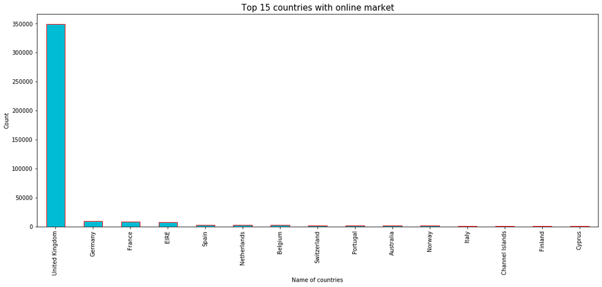

```python
#Checking the different values of country column in the dataset
retail['Country'].value_counts().head(15).plot.bar(figsize = (18,7),edgecolor='red',color='#00bcd4')
plt.title("Top 15 countries with online market",fontsize=15)
plt.xlabel("Name of countries")
plt.ylabel("Count")
plt.show()
```

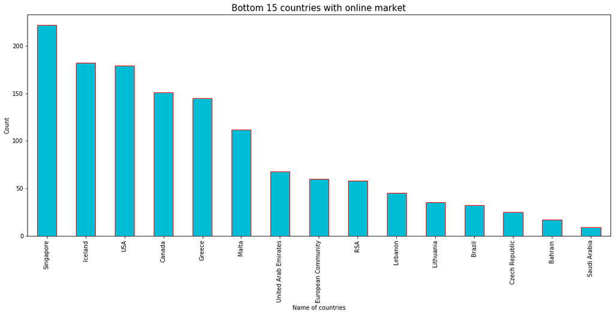

```python
#Checking the different values of country column in the dataset
retail['Country'].value_counts().tail(15).plot.bar(figsize = (18,7),edgecolor='red',color='#00bcd4')
plt.title("Bottom 15 countries with online market",fontsize=15)
plt.xlabel("Name of countries")
plt.ylabel("Count")
plt.show()
```

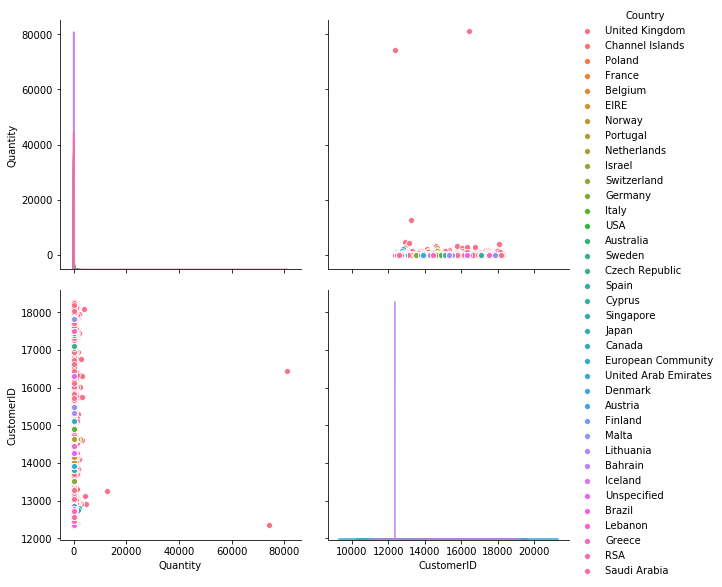

```python
#Pairplot showing the relationship between quantity and customerid
ax=sns.pairplot(data=retail,vars=['Quantity','CustomerID'],hue='Country',height=4,palette='husl')
```

```python
#Checking the maximum quantity of products sold from each country
retail['Quantity'].groupby(retail['Country']).agg('sum').sort_values(ascending=True)
```

```
Country
Saudi Arabia                 80
Bahrain                     260
RSA                         352
Brazil                      356
Lebanon                     386
European Community          499
Lithuania                   652
Czech Republic              671
Malta                       970
United Arab Emirates        982
Greece                     1557
Unspecified                1785
USA                        2458
Iceland                    2458
Canada                     2763
Poland                     3684
Israel                     4043
Austria                    4881
Singapore                  5241
Cyprus                     6340
Italy                      8112
Denmark                    8235
Channel Islands            9485
Finland                   10704
Portugal                  16095
Norway                    19338
Belgium                   23237
Japan                     26016
Spain                     27944
Switzerland               30083
Sweden                    36078
Australia                 84199
France                   111429
Germany                  119156
EIRE                     140383
Netherlands              200937
United Kingdom          4254037
Name: Quantity, dtype: int64
```

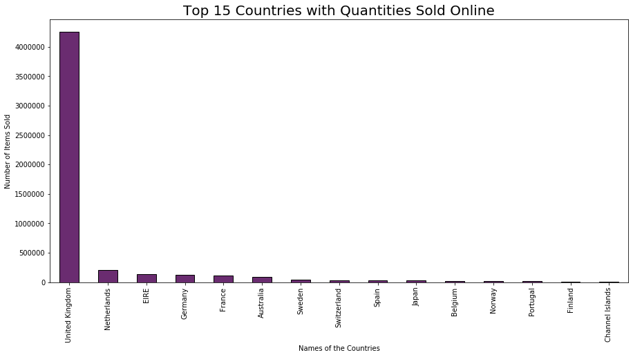

```python
#Top 15 countries in terms of quantities according to countries:
retail['Quantity'].groupby(retail['Country']).agg('sum').sort_values(ascending=False).head(15).plot.bar(figsize = (15, 7),edgecolor='black',color='#6a2c70')
plt.title('Top 15 Countries with Quantities Sold Online', fontsize = 20)
plt.xlabel('Names of the Countries')
plt.ylabel('Number of Items Sold')
plt.show()
```

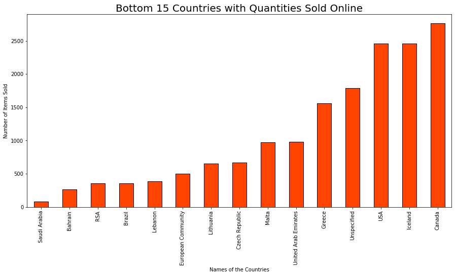

```python
#Bottom 15 countries in terms of quantities according to countries:
retail['Quantity'].groupby(retail['Country']).agg('sum').sort_values(ascending=True).head(15).plot.bar(figsize = (15, 7),edgecolor='black',color='#ff4301')
plt.title('Bottom 15 Countries with Quantities Sold Online', fontsize = 20)
plt.xlabel('Names of the Countries')
plt.ylabel('Number of Items Sold')
plt.show()
```

```python
retail.head()
```

|  | InvoiceNo | StockCode | Description | Quantity | InvoiceDate | UnitPrice | CustomerID | Country |
| --- | --- | --- | --- | --- | --- | --- | --- | --- |
| 1 | 556072 | 20970 | PINK FLORAL FELTCRAFT SHOULDER BAG | 8 | 2011-06-08 14:57:00 | 3.75 | 16126.0 | United Kingdom |
| 2 | 551739 | 21559 | STRAWBERRY LUNCH BOX WITH CUTLERY | 2 | 2011-05-04 10:58:00 | 2.55 | 18118.0 | United Kingdom |
| 3 | 541658 | 21988 | PACK OF 6 SKULL PAPER PLATES | 1 | 2011-01-20 12:16:00 | 0.85 | 15529.0 | United Kingdom |
| 4 | 538364 | 85099C | JUMBO BAG BAROQUE BLACK WHITE | 10 | 2010-12-10 17:26:00 | 1.95 | 14448.0 | United Kingdom |
| 5 | 552306 | 84789 | ENCHANTED BIRD PLANT CAGE | 4 | 2011-05-08 15:20:00 | 3.75 | 13911.0 | United Kingdom |

```python
#Lets see how many orders placed by each customer
n_orders = retail.groupby(['CustomerID'])['InvoiceNo'].nunique()
mult_orders_perc = np.sum(n_orders > 1) / retail['CustomerID'].nunique()
print(f'{100 * mult_orders_perc:.2f}% of customers ordered more than once.')
```

```
65.57% of customers ordered more than once.
```

Using the code above, we can state that 65.57% of customers ordered more than once.

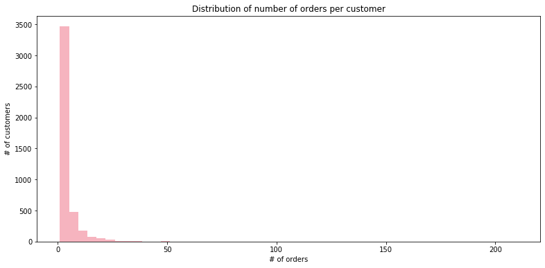

```python
ax = sns.distplot(n_orders, kde=False, hist=True,color='#e94560')
fig=plt.gcf()
fig.set_size_inches(13,6)
ax.set(title='Distribution of number of orders per customer',
       xlabel='# of orders',
       ylabel='# of customers');
```

There are some infrequent cases of customers, who ordered more than 50 times.

Cohort Analysis

The dataset we are using for this example does not contain the customer sign-up date — the date when they registered with the retailer. That is why we assume that the cohort they belong to is based on the first purchase date. A possible downside of this approach is that the dataset does not contain the past data, and what we already see in this snapshot (between 01/12/2010 and 09/12/2011) includes recurring clients. In other words, the first purchase we see in this dataset might not be the actual first purchase of a given client. However, there is no way to account for this without having access to the entire historical dataset of the retailer.

As the second step, we create the cohort and order_month variables. The first one indicates the monthly cohort based on the first purchase date (calculated per customer). The latter one is the truncated month of the purchase date.

```python
retail['order_month'] = retail['InvoiceDate'].dt.to_period('M')
retail['cohort'] = retail.groupby('CustomerID')['InvoiceDate'] \
                 .transform('min') \
                 .dt.to_period('M')
```

```python
retail.head()
```

|  | InvoiceNo | StockCode | Description | Quantity | InvoiceDate | UnitPrice | CustomerID | Country | order_month | cohort |
| --- | --- | --- | --- | --- | --- | --- | --- | --- | --- | --- |
| 1 | 556072 | 20970 | PINK FLORAL FELTCRAFT SHOULDER BAG | 8 | 2011-06-08 14:57:00 | 3.75 | 16126.0 | United Kingdom | 2011-06 | 2011-02 |
| 2 | 551739 | 21559 | STRAWBERRY LUNCH BOX WITH CUTLERY | 2 | 2011-05-04 10:58:00 | 2.55 | 18118.0 | United Kingdom | 2011-05 | 2010-12 |
| 3 | 541658 | 21988 | PACK OF 6 SKULL PAPER PLATES | 1 | 2011-01-20 12:16:00 | 0.85 | 15529.0 | United Kingdom | 2011-01 | 2010-12 |
| 4 | 538364 | 85099C | JUMBO BAG BAROQUE BLACK WHITE | 10 | 2010-12-10 17:26:00 | 1.95 | 14448.0 | United Kingdom | 2010-12 | 2010-12 |
| 5 | 552306 | 84789 | ENCHANTED BIRD PLANT CAGE | 4 | 2011-05-08 15:20:00 | 3.75 | 13911.0 | United Kingdom | 2011-05 | 2011-02 |

Then, we aggregate the data per cohort and order_month and count the number of unique customers in each group. Additionally, we add the period_number, which indicates the number of periods between the cohort month and the month of the purchase.

```python
from operator import attrgetter
```

```python
retail_cohort = retail.groupby(['cohort', 'order_month']) \
              .agg(n_customers=('CustomerID', 'nunique')) \
              .reset_index(drop=False)
retail_cohort['period_number'] = (retail_cohort.order_month - retail_cohort.cohort).apply(attrgetter('n'))
```

```python
retail_cohort.head()
```

|  | cohort | order_month | n_customers | period_number |
| --- | --- | --- | --- | --- |
| 0 | 2010-12 | 2010-12 | 885 | 0 |
| 1 | 2010-12 | 2011-01 | 324 | 1 |
| 2 | 2010-12 | 2011-02 | 286 | 2 |
| 3 | 2010-12 | 2011-03 | 340 | 3 |
| 4 | 2010-12 | 2011-04 | 321 | 4 |

The next step is to pivot the df_cohort table in a way that each row contains information about a given cohort and each column contains values for a certain period.

```python
cohort_pivot = retail_cohort.pivot_table(index = 'cohort',
                                     columns = 'period_number',
                                     values = 'n_customers')
```

To obtain the retention matrix, we need to divide the values each row by the row's first value, which is actually the cohort size — all customers who made their first purchase in the given month.

```python
cohort_size = cohort_pivot.iloc[:,0]
retention_matrix = cohort_pivot.divide(cohort_size, axis = 0)
```

```python
import matplotlib.colors as mcolors
```

Lastly, we plot the retention matrix as a heatmap. Additionally, we wanted to include extra information regarding the cohort size. That is why we in fact created two heatmaps, where the one indicating the cohort size is using a white only colormap — no coloring at all.

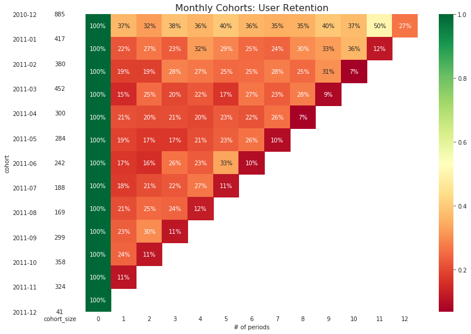

```python
with sns.axes_style("white"):
    fig, ax = plt.subplots(1, 2, figsize=(12, 8), sharey=True, gridspec_kw={'width_ratios': [1, 11]})

    # retention matrix
    sns.heatmap(retention_matrix,
                mask=retention_matrix.isnull(),
                annot=True,
                fmt='.0%',
                cmap='RdYlGn',
                ax=ax[1])
    ax[1].set_title('Monthly Cohorts: User Retention', fontsize=16)
    ax[1].set(xlabel='# of periods',
              ylabel='')

    # cohort size
    cohort_size_df = pd.DataFrame(cohort_size).rename(columns={0: 'cohort_size'})
    white_cmap = mcolors.ListedColormap(['white'])
    sns.heatmap(cohort_size_df,
                annot=True,
                cbar=False,
                fmt='g',
                cmap=white_cmap,
                ax=ax[0])

    fig.tight_layout()
```

In the image, we can see that there is a sharp drop-off in the second month (indexed as 1) already, on average around 80% of customers do not make any purchase in the second month. The first cohort (2010–12) seems to be an exception and performs surprisingly well as compared to the other ones. A year after the first purchase, there is a 50% retention. This might be a cohort of dedicated customers, who first joined the platform based on some already-existing connections with the retailer. However, from data alone, that is very hard to accurately explain. Throughout the matrix, we can see fluctuations in retention over time. This might be caused by the characteristics of the business, where clients do periodic purchases, followed by periods of inactivity.

```python
### Trying one more time
import datetime as dt
def get_month(x) : return dt.datetime(x.year,x.month,1)
retail['InvoiceMonth'] = retail['InvoiceDate'].apply(get_month)
grouping = retail.groupby('CustomerID')['InvoiceMonth']
retail['CohortMonth'] = grouping.transform('min')
retail.tail()
```

|  | InvoiceNo | StockCode | Description | Quantity | InvoiceDate | UnitPrice | CustomerID | Country | order_month | cohort | InvoiceMonth | CohortMonth |
| --- | --- | --- | --- | --- | --- | --- | --- | --- | --- | --- | --- | --- |
| 162568 | 574102 | 22866 | HAND WARMER SCOTTY DOG DESIGN | 24 | 2011-11-03 10:27:00 | 2.10 | 16128.0 | United Kingdom | 2011-11 | 2011-03 | 2011-11-01 | 2011-03-01 |
| 162569 | 545226 | 22919 | HERB MARKER MINT | 12 | 2011-03-01 09:33:00 | 0.65 | 12428.0 | Finland | 2011-03 | 2011-03 | 2011-03-01 | 2011-03-01 |
| 162570 | 573160 | 22077 | 6 RIBBONS RUSTIC CHARM | 12 | 2011-10-28 08:58:00 | 1.95 | 14359.0 | United Kingdom | 2011-10 | 2011-09 | 2011-10-01 | 2011-09-01 |
| 162571 | 552321 | 23204 | CHARLOTTE BAG APPLES DESIGN | 10 | 2011-05-09 09:15:00 | 0.85 | 17049.0 | United Kingdom | 2011-05 | 2011-03 | 2011-05-01 | 2011-03-01 |
| 162572 | 573359 | 21983 | PACK OF 12 BLUE PAISLEY TISSUES | 4 | 2011-10-30 12:48:00 | 0.39 | 14178.0 | United Kingdom | 2011-10 | 2011-06 | 2011-10-01 | 2011-06-01 |

```python
def get_month_int (dframe,column):
    year = dframe[column].dt.year
    month = dframe[column].dt.month
    day = dframe[column].dt.day
    return year, month , day

invoice_year,invoice_month,_ = get_month_int(retail,'InvoiceMonth')
cohort_year,cohort_month,_ = get_month_int(retail,'CohortMonth')

year_diff = invoice_year - cohort_year
month_diff = invoice_month - cohort_month

retail['CohortIndex'] = year_diff * 12 + month_diff + 1
```

```python
#Count monthly active customers from each cohort
grouping = retail.groupby(['CohortMonth', 'CohortIndex'])
cohort_data = grouping['CustomerID'].apply(pd.Series.nunique)
# Return number of unique elements in the object.
cohort_data = cohort_data.reset_index()
cohort_counts = cohort_data.pivot(index='CohortMonth',columns='CohortIndex',values='CustomerID')
cohort_counts
```

| CohortIndex CohortMonth | 1 | 2 | 3 | 4 | 5 | 6 | 7 | 8 | 9 | 10 | 11 | 12 | 13 |
| --- | --- | --- | --- | --- | --- | --- | --- | --- | --- | --- | --- | --- | --- |
| 2010-12-01 | 885.0 | 324.0 | 286.0 | 340.0 | 321.0 | 352.0 | 321.0 | 309.0 | 313.0 | 350.0 | 331.0 | 445.0 | 235.0 |
| 2011-01-01 | 417.0 | 92.0 | 111.0 | 96.0 | 134.0 | 120.0 | 103.0 | 101.0 | 125.0 | 136.0 | 152.0 | 49.0 | NaN |
| 2011-02-01 | 380.0 | 71.0 | 71.0 | 108.0 | 103.0 | 94.0 | 96.0 | 106.0 | 94.0 | 116.0 | 26.0 | NaN | NaN |
| 2011-03-01 | 452.0 | 68.0 | 114.0 | 90.0 | 101.0 | 76.0 | 121.0 | 104.0 | 126.0 | 39.0 | NaN | NaN | NaN |
| 2011-04-01 | 300.0 | 64.0 | 61.0 | 63.0 | 59.0 | 68.0 | 65.0 | 78.0 | 22.0 | NaN | NaN | NaN | NaN |
| 2011-05-01 | 284.0 | 54.0 | 49.0 | 49.0 | 59.0 | 66.0 | 75.0 | 27.0 | NaN | NaN | NaN | NaN | NaN |
| 2011-06-01 | 242.0 | 42.0 | 38.0 | 64.0 | 56.0 | 81.0 | 23.0 | NaN | NaN | NaN | NaN | NaN | NaN |
| 2011-07-01 | 188.0 | 34.0 | 39.0 | 42.0 | 51.0 | 21.0 | NaN | NaN | NaN | NaN | NaN | NaN | NaN |
| 2011-08-01 | 169.0 | 35.0 | 42.0 | 41.0 | 21.0 | NaN | NaN | NaN | NaN | NaN | NaN | NaN | NaN |
| 2011-09-01 | 299.0 | 70.0 | 90.0 | 34.0 | NaN | NaN | NaN | NaN | NaN | NaN | NaN | NaN | NaN |
| 2011-10-01 | 358.0 | 86.0 | 41.0 | NaN | NaN | NaN | NaN | NaN | NaN | NaN | NaN | NaN | NaN |
| 2011-11-01 | 324.0 | 36.0 | NaN | NaN | NaN | NaN | NaN | NaN | NaN | NaN | NaN | NaN | NaN |
| 2011-12-01 | 41.0 | NaN | NaN | NaN | NaN | NaN | NaN | NaN | NaN | NaN | NaN | NaN | NaN |

```python
# Retention table
cohort_size = cohort_counts.iloc[:,0]
retention = cohort_counts.divide(cohort_size,axis=0) #axis=0 to ensure the divide along the row axis
retention.round(3) * 100 #to show the number as percentage
```

| CohortIndex CohortMonth | 1 | 2 | 3 | 4 | 5 | 6 | 7 | 8 | 9 | 10 | 11 | 12 | 13 |
| --- | --- | --- | --- | --- | --- | --- | --- | --- | --- | --- | --- | --- | --- |
| 2010-12-01 | 100.0 | 36.6 | 32.3 | 38.4 | 36.3 | 39.8 | 36.3 | 34.9 | 35.4 | 39.5 | 37.4 | 50.3 | 26.6 |
| 2011-01-01 | 100.0 | 22.1 | 26.6 | 23.0 | 32.1 | 28.8 | 24.7 | 24.2 | 30.0 | 32.6 | 36.5 | 11.8 | NaN |
| 2011-02-01 | 100.0 | 18.7 | 18.7 | 28.4 | 27.1 | 24.7 | 25.3 | 27.9 | 24.7 | 30.5 | 6.8 | NaN | NaN |
| 2011-03-01 | 100.0 | 15.0 | 25.2 | 19.9 | 22.3 | 16.8 | 26.8 | 23.0 | 27.9 | 8.6 | NaN | NaN | NaN |
| 2011-04-01 | 100.0 | 21.3 | 20.3 | 21.0 | 19.7 | 22.7 | 21.7 | 26.0 | 7.3 | NaN | NaN | NaN | NaN |
| 2011-05-01 | 100.0 | 19.0 | 17.3 | 17.3 | 20.8 | 23.2 | 26.4 | 9.5 | NaN | NaN | NaN | NaN | NaN |
| 2011-06-01 | 100.0 | 17.4 | 15.7 | 26.4 | 23.1 | 33.5 | 9.5 | NaN | NaN | NaN | NaN | NaN | NaN |
| 2011-07-01 | 100.0 | 18.1 | 20.7 | 22.3 | 27.1 | 11.2 | NaN | NaN | NaN | NaN | NaN | NaN | NaN |
| 2011-08-01 | 100.0 | 20.7 | 24.9 | 24.3 | 12.4 | NaN | NaN | NaN | NaN | NaN | NaN | NaN | NaN |
| 2011-09-01 | 100.0 | 23.4 | 30.1 | 11.4 | NaN | NaN | NaN | NaN | NaN | NaN | NaN | NaN | NaN |
| 2011-10-01 | 100.0 | 24.0 | 11.5 | NaN | NaN | NaN | NaN | NaN | NaN | NaN | NaN | NaN | NaN |
| 2011-11-01 | 100.0 | 11.1 | NaN | NaN | NaN | NaN | NaN | NaN | NaN | NaN | NaN | NaN | NaN |
| 2011-12-01 | 100.0 | NaN | NaN | NaN | NaN | NaN | NaN | NaN | NaN | NaN | NaN | NaN | NaN |

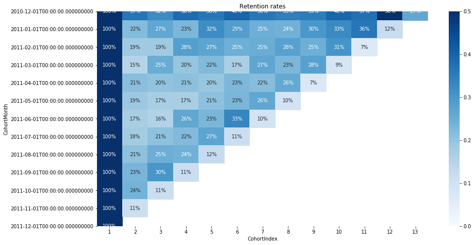

```python
#Build the heatmap
plt.figure(figsize=(15, 8))
plt.title('Retention rates')
sns.heatmap(data=retention,annot = True,fmt = '.0%',vmin = 0.0,vmax = 0.5,cmap="Blues")
plt.show()
```

# Average quantity for each cohort

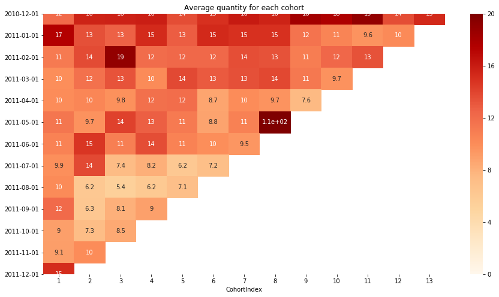

```python
#Average quantity for each cohort
grouping = retail.groupby(['CohortMonth', 'CohortIndex'])
cohort_data = grouping['Quantity'].mean()
cohort_data = cohort_data.reset_index()
average_quantity = cohort_data.pivot(index='CohortMonth',columns='CohortIndex',values='Quantity')
average_quantity.round(1)
average_quantity.index = average_quantity.index.date

#Build the heatmap
plt.figure(figsize=(15, 8))
plt.title('Average quantity for each cohort')
sns.heatmap(data=average_quantity,annot = True,vmin = 0.0,vmax =20,cmap="OrRd")
plt.show()
```

Project Task: Week 2 Data Modeling :

1. Build a RFM (Recency Frequency Monetary) model. Recency means the number of days since a customer made the last purchase. Frequency is the number of purchase in a given period. It could be 3 months, 6 months or 1 year. Monetary is the total amount of money a customer spent in that given period. Therefore, big spenders will be differentiated among other customers such as MVP (Minimum Viable Product) or VIP.
2. Calculate RFM metrics.
3. Build RFM Segments. Give recency, frequency, and monetary scores individually by dividing them into quartiles.

b1. Combine three ratings to get a RFM segment (as strings).

b2. Get the RFM score by adding up the three ratings.

b3. Analyze the RFM segments by summarizing them and comment on the findings.

Note: Rate “recency" for customer who has been active more recently higher than the less recent customer, because each company wants its customers to be recent.

Note: Rate “frequency" and “monetary" higher, because the company wants the customer to visit more often and spend more money

The RFM values can be grouped in several ways:

1.Percentiles e.g. quantiles

2.Pareto 80/20 cut

3.Custom - based on business knowledge

We are going to implement percentile-based grouping.

Process of calculating percentiles:

Sort customers based on that metric

Break customers into a pre-defined number of groups of equal size

Assign a label to each group

```python
#New Total Sum Column
retail['TotalSum'] = retail['UnitPrice']* retail['Quantity']

#Data preparation steps
print('Min Invoice Date:',retail.InvoiceDate.dt.date.min(),'max Invoice Date:',
       retail.InvoiceDate.dt.date.max())

retail.head(3)
```

```
Min Invoice Date: 2010-12-01 max Invoice Date: 2011-12-09
```

|  | InvoiceNo | StockCode | Description | Quantity | InvoiceDate | UnitPrice | CustomerID | Country | order_month | cohort | InvoiceMonth | CohortMonth | CohortIndex | TotalSum |
| --- | --- | --- | --- | --- | --- | --- | --- | --- | --- | --- | --- | --- | --- | --- |
| 1 | 556072 | 20970 | PINK FLORAL FELTCRAFT SHOULDER BAG | 8 | 2011-06-08 14:57:00 | 3.75 | 16126.0 | United Kingdom | 2011-06 | 2011-02 | 2011-06-01 | 2011-02-01 | 5 | 30.00 |
| 2 | 551739 | 21559 | STRAWBERRY LUNCH BOX WITH CUTLERY | 2 | 2011-05-04 10:58:00 | 2.55 | 18118.0 | United Kingdom | 2011-05 | 2010-12 | 2011-05-01 | 2010-12-01 | 6 | 5.10 |
| 3 | 541658 | 21988 | PACK OF 6 SKULL PAPER PLATES | 1 | 2011-01-20 12:16:00 | 0.85 | 15529.0 | United Kingdom | 2011-01 | 2010-12 | 2011-01-01 | 2010-12-01 | 2 | 0.85 |

```python
snapshot_date = retail['InvoiceDate'].max() + dt.timedelta(days=1)
snapshot_date
#The last day of purchase in total is 09 DEC, 2011. To calculate the day periods,
#let's set one day after the last one,or
#10 DEC as a snapshot_date. We will cound the diff days with snapshot_date.
```

```
Timestamp('2011-12-10 12:50:00')
```

```python
# Calculate RFM metrics
rfm = retail.groupby(['CustomerID']).agg({'InvoiceDate': lambda x : (snapshot_date - x.max()).days,
                                      'InvoiceNo':'count','TotalSum': 'sum'})
#Function Lambdea: it gives the number of days between hypothetical today and the last transaction

#Rename columns
rfm.rename(columns={'InvoiceDate':'Recency','InvoiceNo':'Frequency','TotalSum':'MonetaryValue'}
           ,inplace= True)

#Final RFM values
rfm.head()
```

| CustomerID | Recency | Frequency | MonetaryValue |
| --- | --- | --- | --- |
| 12346.0 | 326 | 1 | 77183.60 |
| 12347.0 | 2 | 182 | 4310.00 |
| 12348.0 | 75 | 31 | 1797.24 |
| 12349.0 | 19 | 73 | 1757.55 |
| 12350.0 | 310 | 17 | 334.40 |

Note That :

We will rate "Recency" customer who have been active more recently better than the less recent customer,because each company wants its customers to be recent We will rate "Frequency" and "Monetary Value" higher label because we want Customer to spend more money and visit more often(that is different order than recency).

```python
#Building RFM segments
r_labels =range(4,0,-1)
f_labels=range(1,5)
m_labels=range(1,5)
r_quartiles = pd.qcut(rfm['Recency'], q=4, labels = r_labels)
f_quartiles = pd.qcut(rfm['Frequency'],q=4, labels = f_labels)
m_quartiles = pd.qcut(rfm['MonetaryValue'],q=4,labels = m_labels)
rfm = rfm.assign(R=r_quartiles,F=f_quartiles,M=m_quartiles)

# Build RFM Segment and RFM Score
def add_rfm(x) : return str(x['R']) + str(x['F']) + str(x['M'])
rfm['RFM_Segment'] = rfm.apply(add_rfm,axis=1 )
rfm['RFM_Score'] = rfm[['R','F','M']].sum(axis=1)

rfm.head()
```

| CustomerID | Recency | Frequency | MonetaryValue | R | F | M | RFM_Segment | RFM_Score |
| --- | --- | --- | --- | --- | --- | --- | --- | --- |
| 12346.0 | 326 | 1 | 77183.60 | 1 | 1 | 4 | 114 | 6.0 |
| 12347.0 | 2 | 182 | 4310.00 | 4 | 4 | 4 | 444 | 12.0 |
| 12348.0 | 75 | 31 | 1797.24 | 2 | 2 | 4 | 224 | 8.0 |
| 12349.0 | 19 | 73 | 1757.55 | 3 | 3 | 4 | 334 | 10.0 |
| 12350.0 | 310 | 17 | 334.40 | 1 | 1 | 2 | 112 | 4.0 |

The Result is a Table which has a row for each customer with their RFM

# Analyzing RFM Segments

Largest RFM segments It is always the best practice to investigate the size of the segments before you use them for targeting or other business Application.

```python
rfm.groupby(['RFM_Segment']).size().sort_values(ascending=False)[:5]
```

```
RFM_Segment
444    450
111    381
344    217
122    206
211    179
dtype: int64
```

# Filtering on RFM segments

```python
#Select bottom RFM segment "111" and view top 5 rows
rfm[rfm['RFM_Segment']=='111'].head()
```

| CustomerID | Recency | Frequency | MonetaryValue | R | F | M | RFM_Segment | RFM_Score |
| --- | --- | --- | --- | --- | --- | --- | --- | --- |
| 12353.0 | 204 | 4 | 89.00 | 1 | 1 | 1 | 111 | 3.0 |
| 12361.0 | 287 | 10 | 189.90 | 1 | 1 | 1 | 111 | 3.0 |
| 12401.0 | 303 | 5 | 84.30 | 1 | 1 | 1 | 111 | 3.0 |
| 12402.0 | 323 | 11 | 225.60 | 1 | 1 | 1 | 111 | 3.0 |
| 12441.0 | 367 | 11 | 173.55 | 1 | 1 | 1 | 111 | 3.0 |

# Summary metrics per RFM Score

```python
rfm.groupby('RFM_Score').agg({'Recency': 'mean','Frequency': 'mean',
                             'MonetaryValue': ['mean', 'count'] }).round(1)
```

| RFM_Score | Recency mean | Frequency mean | MonetaryValue mean | MonetaryValue count |
| --- | --- | --- | --- | --- |
| 3.0 | 260.7 | 8.2 | 157.4 | 381 |
| 4.0 | 177.2 | 13.6 | 240.0 | 388 |
| 5.0 | 152.9 | 21.2 | 366.6 | 518 |
| 6.0 | 95.9 | 27.8 | 820.1 | 457 |
| 7.0 | 79.4 | 37.9 | 757.1 | 464 |
| 8.0 | 64.1 | 56.0 | 987.3 | 454 |
| 9.0 | 45.9 | 78.7 | 1795.1 | 414 |
| 10.0 | 32.4 | 110.5 | 2056.4 | 426 |
| 11.0 | 21.3 | 186.9 | 4062.0 | 387 |
| 12.0 | 7.2 | 367.9 | 9285.9 | 450 |

# Use RFM score to group customers into Gold, Silver and Bronze segments

```python
def segments(df):
    if df['RFM_Score'] > 9 :
        return 'Gold'
    elif (df['RFM_Score'] > 5) and (df['RFM_Score'] <= 9 ):
        return 'Sliver'
    else:
        return 'Bronze'

rfm['General_Segment'] = rfm.apply(segments,axis=1)

rfm.groupby('General_Segment').agg({'Recency':'mean','Frequency':'mean',
                                    'MonetaryValue':['mean','count']}).round(1)
```

| General_Segment | Recency mean | Frequency mean | MonetaryValue mean | MonetaryValue count |
| --- | --- | --- | --- | --- |
| Bronze | 192.2 | 15.1 | 266.5 | 1287 |
| Gold | 20.1 | 225.6 | 5246.8 | 1263 |
| Sliver | 72.0 | 49.4 | 1071.8 | 1789 |

Data Pre-Processing for Kmeans Clustering

We must check these Key k-means assumptions before we implement our Kmeans Clustering Mode

Symmetric distribution of variables (not skewed)

Variables with same average values

Variables with same variance

```python
rfm_rfm = rfm[['Recency','Frequency','MonetaryValue']]
print(rfm_rfm.describe())
```

```
           Recency    Frequency  MonetaryValue
count  4339.000000  4339.000000    4339.000000
mean     92.518322    90.512100    2048.215924
std     100.009747   225.515328    8984.248352
min       1.000000     1.000000       0.000000
25%      18.000000    17.000000     306.455000
50%      51.000000    41.000000     668.560000
75%     142.000000    98.000000    1660.315000
max     374.000000  7676.000000  280206.020000
```

```python
rfm['MonetaryValue']=rfm['MonetaryValue'].astype('int64')
```

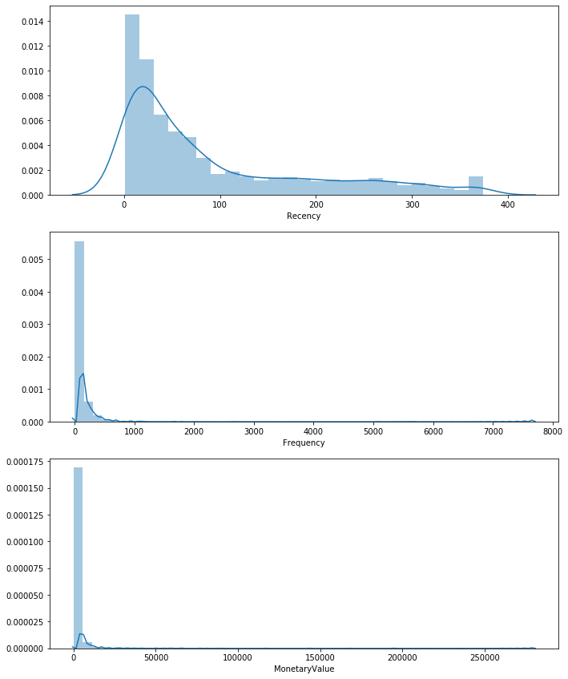

```python
# plot the distribution of RFM values
f,ax = plt.subplots(figsize=(10, 12))
plt.subplot(3, 1, 1); sns.distplot(rfm.Recency, label = 'Recency')
plt.subplot(3, 1, 2); sns.distplot(rfm.Frequency, label = 'Frequency')
plt.subplot(3, 1, 3); sns.distplot(rfm.MonetaryValue, label = 'Monetary Value')
plt.style.use('fivethirtyeight')
plt.tight_layout()
plt.show()
```

Also, there is another Problem: UnSymmetric distribution of variables (data skewed)

We use these Sequence of structuring pre-processing steps:

Standardize to the same average values

Scale to the same standard deviation

Store as a separate array to be used for clustering

Why the sequence matters?

Log transformation only works with positive data

Normalization forces data to have negative values and log will not work

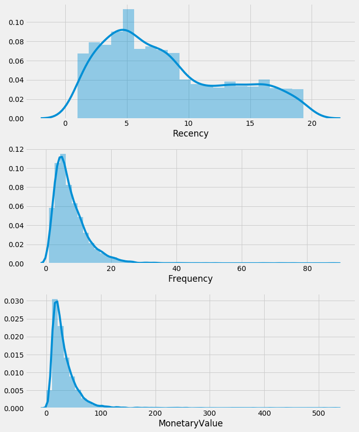

```python
#Unskew the data with log transformation
rfm_log = rfm[['Recency', 'Frequency', 'MonetaryValue']].apply(np.sqrt, axis = 1).round(3)
#rfm_log = np.log(rfm_rfm)


# plot the distribution of RFM values
f,ax = plt.subplots(figsize=(10, 12))
plt.subplot(3, 1, 1); sns.distplot(rfm_log.Recency, label = 'Recency')
plt.subplot(3, 1, 2); sns.distplot(rfm_log.Frequency, label = 'Frequency')
plt.subplot(3, 1, 3); sns.distplot(rfm_log.MonetaryValue, label = 'Monetary Value')
plt.style.use('fivethirtyeight')
plt.tight_layout()
plt.show()
```

Project Task: Week 3

Data Modeling :

1. Create clusters using k-means clustering algorithm.

a. Prepare the data for the algorithm. If the data is asymmetrically distributed, manage the skewness with appropriate transformation. Standardize the data.

b. Decide the optimum number of clusters to be formed.

c. Analyze these clusters and comment on the results.

```python
#Normalize the variables with StandardScaler
from sklearn.preprocessing import StandardScaler
scaler = StandardScaler()
scaler.fit(rfm_log)
#Store it separately for clustering
rfm_normalized= scaler.transform(rfm_log)
```

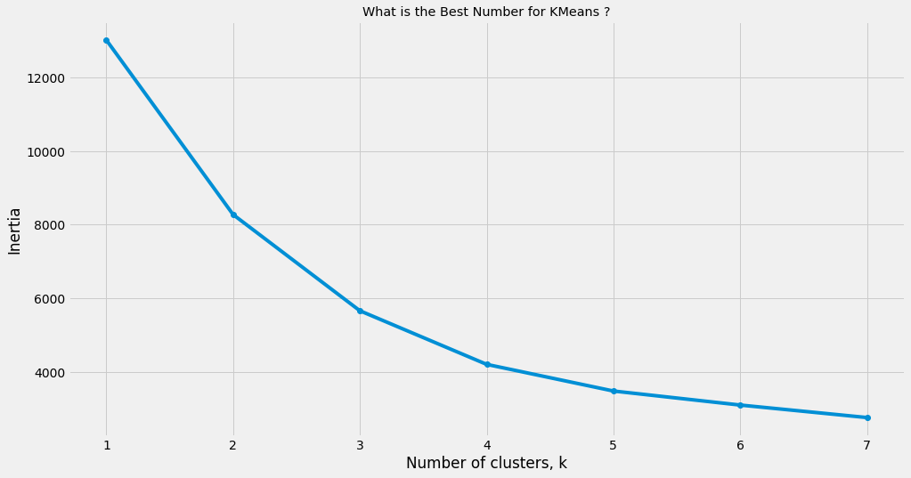

```python
from sklearn.cluster import KMeans

#First : Get the Best KMeans
ks = range(1,8)
inertias=[]
for k in ks :
    # Create a KMeans clusters
    kc = KMeans(n_clusters=k,random_state=1)
    kc.fit(rfm_normalized)
    inertias.append(kc.inertia_)

# Plot ks vs inertias
f, ax = plt.subplots(figsize=(15, 8))
plt.plot(ks, inertias, '-o')
plt.xlabel('Number of clusters, k')
plt.ylabel('Inertia')
plt.xticks(ks)
plt.style.use('ggplot')
plt.title('What is the Best Number for KMeans ?')
plt.show()
```

Note That: We Choose No.KMeans = 3

```python
# clustering
kc = KMeans(n_clusters= 3, random_state=1)
kc.fit(rfm_normalized)

#Create a cluster label column in the original DataFrame
cluster_labels = kc.labels_

#Calculate average RFM values and size for each cluster:
rfm_rfm_k3 = rfm_rfm.assign(K_Cluster = cluster_labels)

#Calculate average RFM values and sizes for each cluster:
rfm_rfm_k3.groupby('K_Cluster').agg({'Recency': 'mean','Frequency': 'mean',
                                         'MonetaryValue': ['mean', 'count'],}).round(0)
```

| K_Cluster | Recency mean | Frequency mean | MonetaryValue mean | MonetaryValue count |
| --- | --- | --- | --- | --- |
| 0 | 39.0 | 59.0 | 1033.0 | 2449 |
| 1 | 225.0 | 27.0 | 489.0 | 1305 |
| 2 | 19.0 | 364.0 | 9778.0 | 585 |

Snake plots to understand and compare segments

Market research technique to compare different segments

Visual representation of each segment's attributes

Need to first normalize data (center & scale)

Plot each cluster's average normalized values of each attribute

```python
rfm_normalized = pd.DataFrame(rfm_normalized,index=rfm_rfm.index,columns=rfm_rfm.columns)
rfm_normalized['K_Cluster'] = kc.labels_
rfm_normalized['General_Segment'] = rfm['General_Segment']
rfm_normalized.reset_index(inplace = True)

#Melt the data into a long format so RFM values and metric names are stored in 1 column each
rfm_melt = pd.melt(rfm_normalized,id_vars=['CustomerID','General_Segment','K_Cluster'],value_vars=['Recency', 'Frequency', 'MonetaryValue'],
var_name='Metric',value_name='Value')
rfm_melt.head()
```

|  | CustomerID | General_Segment | K_Cluster | Metric | Value |
| --- | --- | --- | --- | --- | --- |
| 0 | 12346.0 | Sliver | 2 | Recency | 1.964145 |
| 1 | 12347.0 | Gold | 2 | Recency | -1.355554 |
| 2 | 12348.0 | Sliver | 0 | Recency | 0.089944 |
| 3 | 12349.0 | Gold | 0 | Recency | -0.768058 |
| 4 | 12350.0 | Bronze | 1 | Recency | 1.874773 |

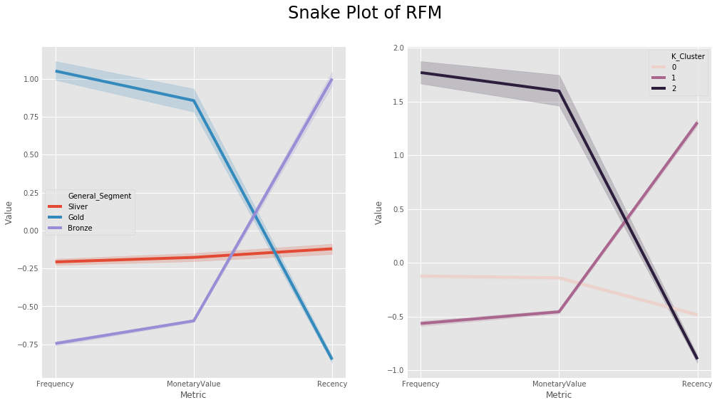

```python
f, (ax1, ax2) = plt.subplots(1,2, figsize=(15, 8))
sns.lineplot(x = 'Metric', y = 'Value', hue = 'General_Segment', data = rfm_melt,ax=ax1)

# a snake plot with K-Means
sns.lineplot(x = 'Metric', y = 'Value', hue = 'K_Cluster', data = rfm_melt,ax=ax2)

plt.suptitle("Snake Plot of RFM",fontsize=24) #make title fontsize subtitle
plt.show()
```

Relative importance of segment attributes

Useful technique to identify relative importance of each segment's attribute

1.Calculate average values of each cluster

2.Calculate average values of population

3.Calculate importance score by dividing them and subtracting 1 (ensures 0 is returned when cluster average equals population average)

Let’s try again with a heat map. Heat maps are a graphical representation of data where larger values were colored in darker scales and smaller values in lighter scales. We can compare the variance between the groups quite intuitively by colors.

```python
# The further a ratio is from 0, the more important that attribute is for a segment relative to the total population
cluster_avg = rfm_rfm_k3.groupby(['K_Cluster']).mean()
population_avg = rfm_rfm.mean()
relative_imp = cluster_avg / population_avg - 1
relative_imp.round(2)
```

| K_Cluster | Recency | Frequency | MonetaryValue |
| --- | --- | --- | --- |
| 0 | -0.57 | -0.35 | -0.50 |
| 1 | 1.43 | -0.70 | -0.76 |
| 2 | -0.79 | 3.02 | 3.77 |

```python
# the mean value in total
total_avg = rfm.iloc[:, 0:3].mean()
# calculate the proportional gap with total mean
cluster_avg = rfm.groupby('General_Segment').mean().iloc[:, 0:3]
prop_rfm = cluster_avg/total_avg - 1
prop_rfm.round(2)
```

| General_Segment | Recency | Frequency | MonetaryValue |
| --- | --- | --- | --- |
| Bronze | 1.08 | -0.83 | -0.87 |
| Gold | -0.78 | 1.49 | 1.56 |
| Sliver | -0.22 | -0.45 | -0.48 |

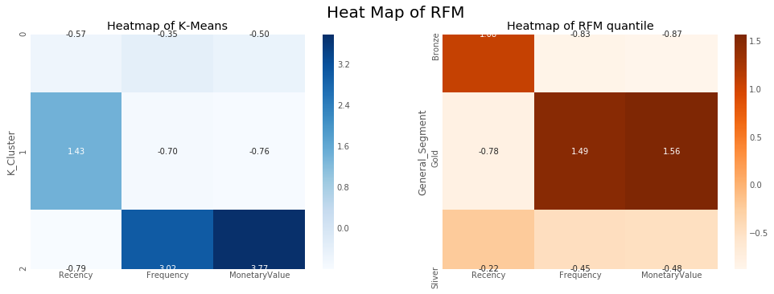

```python
# heatmap with RFM
f, (ax1, ax2) = plt.subplots(1,2, figsize=(15, 5))
sns.heatmap(data=relative_imp, annot=True, fmt='.2f', cmap='Blues',ax=ax1)
ax1.set(title = "Heatmap of K-Means")

# a snake plot with K-Means
sns.heatmap(prop_rfm, cmap= 'Oranges', fmt= '.2f', annot = True,ax=ax2)
ax2.set(title = "Heatmap of RFM quantile")

plt.suptitle("Heat Map of RFM",fontsize=20) #make title fontsize subtitle

plt.show()
```

# Project Task: Week 4

Data Reporting:

1. Create a dashboard in tableau by choosing appropriate chart types and metrics useful for the business. The dashboard must entail the following:

a. Country-wise analysis to demonstrate average spend. Use a bar chart to show the monthly figures

b. Bar graph of top 15 products which are mostly ordered by the users to show the number of products sold

c. Bar graph to show the count of orders vs. hours throughout the day

d. Plot the distribution of RFM values using histogram and frequency charts

e. Plot error (cost) vs. number of clusters selected

f. Visualize to compare the RFM values of the clusters using heatmap

# For Tableau Dashboard[click here](https://public.tableau.com/profile/b.hemanth.kumar#!/vizhome/PGP-RetailAnalysis/PGP-Retail?publish=yes)

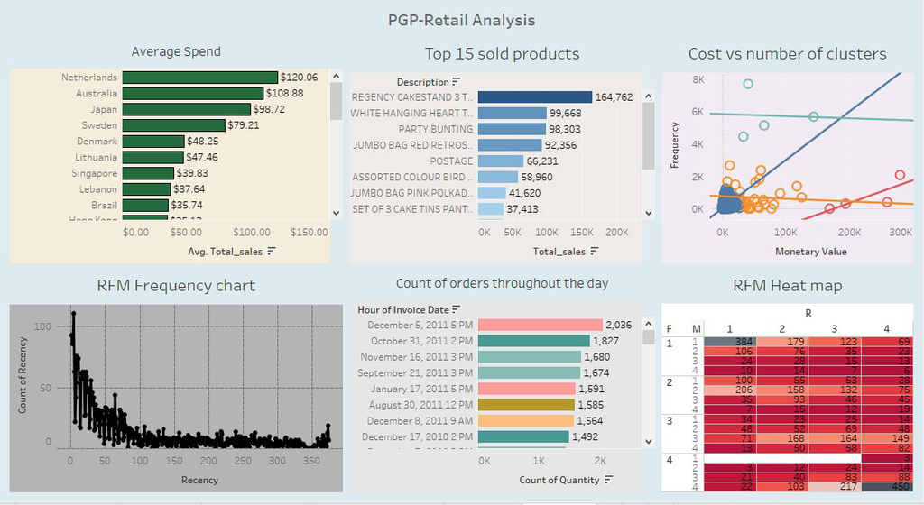

```python
from PIL import Image as PILImage
import base64, io, IPython
image = PILImage.open('Pgp-Retail analysis.jpg')
output = io.BytesIO()
image.save(output, format='PNG')
encoded_string = base64.b64encode(output.getvalue()).decode()
html = '<img src="data:…"/>'.format(encoded_string)
IPython.display.HTML(html)
```